# Aula 9

Renan Tomazini

2022-08-29

# Título

## Título 2

### Título 3

#### Título 4

Texto em **Negrito** Texto em *Itálico* Código `Print Hello world`

Inclusão de link: Rural

# Abas

## Aba de A

Aaa aa aaa aaaa aaaaa Aaa aa aaa aaaa aaaaa Aaa aa aaa aaaa aaaaa Aaa aa aaa aaaa aaaaa

## Aba de b

Bbb b bbb bbbb bbbbbb Bbb b bbb bbbb bbbbbb Bbb b bbb bbbb bbbbbb Bbb b bbb bbbb bbbbbb Bbb b bbb bbbb bbbbbb

# Chunks

São blocos de códigos executados quando o documento é compilado. Para inserir basta: `{r nome do chunk} <código>`

Aqui tem um gráfico:

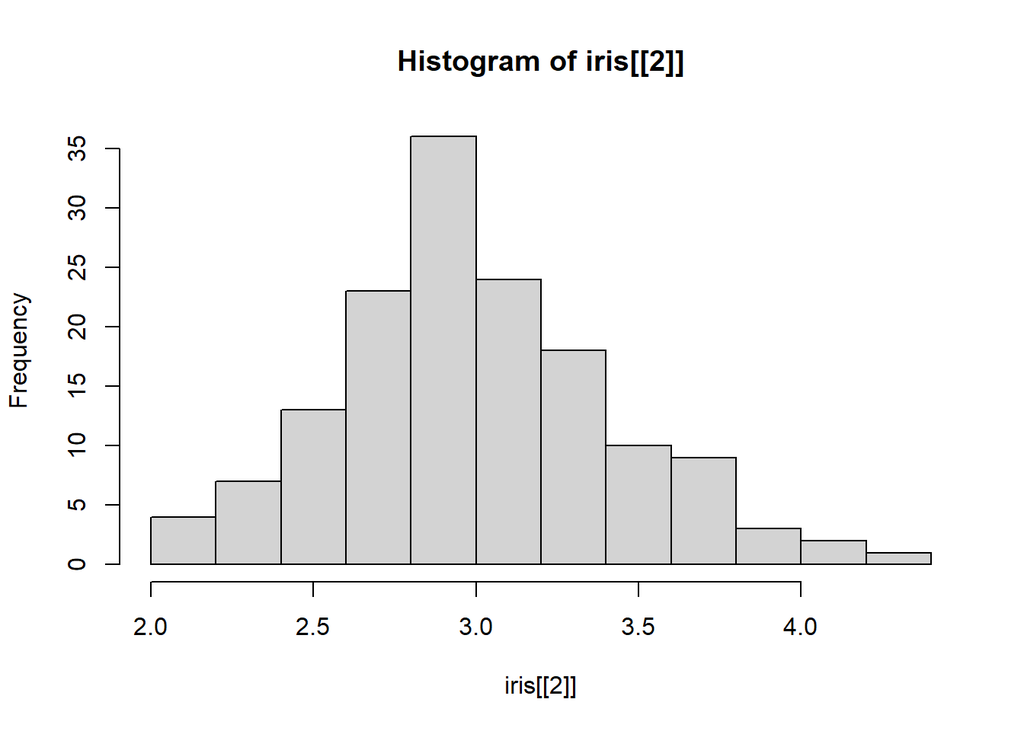

```r
hist(iris[[2]])
```

## Opções em Chunks

echo: Inclui o código do chunk (TRUE) ou não (FALSE) no documento compilado.

results: Se results=“hide” os resultados não são apresentados, mas o código é apresentado.

include:Determina se o chunk e a saída serão apresentados no documento final.Seinclude=FALSE nemo código nem o resultado será mostrado.

warning, messagee error: Se irá mostrar mensagens, warnings ou erros.

```
## [1] 0.8916078
```

```r
x <- rnorm(100)
y <- 2*x + rnorm(100)
cor(x,y)
```

```r
x <- rnorm(100)
y <- 2*x + rnorm(100)
cor(x,y)
```

```
## [1] 0.9008879
```

## Código in-line

Obter o valor a partir do código. Existem 150 opções em iris

## Tabelas

```r
head(iris)
```

```
##   Sepal.Length Sepal.Width Petal.Length Petal.Width Species
## 1          5.1         3.5          1.4         0.2  setosa
## 2          4.9         3.0          1.4         0.2  setosa
## 3          4.7         3.2          1.3         0.2  setosa
## 4          4.6         3.1          1.5         0.2  setosa
## 5          5.0         3.6          1.4         0.2  setosa
## 6          5.4         3.9          1.7         0.4  setosa
```

## inserir figura

[figure not shown]

Figura

## Equações

Use Latex, exemplos: $Y = \beta_0 +beta_1 x + \epsilon$

Para centralizar em linha própria:
$$Y =
\beta_0 +beta_1 x + \epsilon$$

## Criando referências

Para usar o recurso é necessário especificar o nome do arquivo (.bib) usando o campo bibliographu no cabeçalho do documento. Pegar o id do trabalho, usar a @ na frente em qualquer parte do documento para ele aparecer nas referencias finais.

### Citar o trabalho:

Basta colocar a arroba a referencia após o texto Redmalm (2014) Dessa forma Allaire (2012) e dessa Dhar (2013) Verzani (2011)

## RPubs

Publicar os relatorios no RPubs

# Referências

Allaire, J. 2012. “RStudio: Integrated Development Environment for r.” *Boston, MA* 770 (394): 165–71.

Dhar, Vasant. 2013. “Data Science and Prediction.” *Communications of the ACM* 56 (12): 64–73.

Redmalm, David. 2014. “Holy Bonsai Wolves: Chihuahuas and the Paris Hilton Syndrome.” *International Journal of Cultural Studies* 17 (1): 93–109.

Verzani, John. 2011. *Getting Started with RStudio*. " O’Reilly Media, Inc.".